# RSA Assessment: Florida Atlantic Coastal Lowlands Ecological Section

Authors

Randy Swaty (rswaty@tnc.org)

Carly Evans (c.evans@us.fsc.org)

Published

September 18, 2026

## Introduction

Principle 6 of the [FSC US Forest Stewardship Standard (FSS)](https://us.fsc.org/forest-management/revised-fscr-us-forest-stewardship-standard-v2) aims to maximize positive environmental impacts and minimize adverse environmental impacts of management activities occurring within certified management units. Toward this desired outcome, Criterion 6.5 requires the identification and protection or restoration of native ecosystems that are not already adequately represented and protected in the landscape, defined here as the Ecological Section named above, and in the locator map to the right.

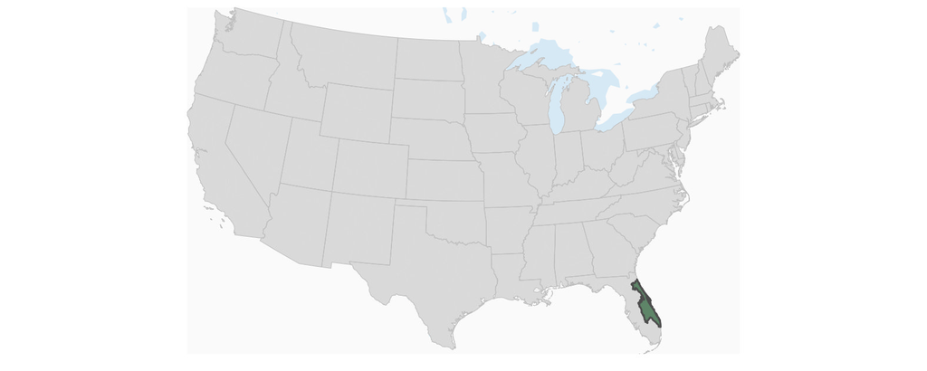

This tool serves to support certificate holders with the requirements of Criterion 6.5 related to Representative Sample Areas (RSAs), but importantly, does not ensure conformance. Additional information gathering and evaluation will most likely be required by certificate holders to ensure conformance with the elements of Criterion 6.5. It is not possible to establish a blanket measurement by which to determine “adequate” protection of all various and complex native ecosystems across the entirety of the conterminous US.

This tool primarily helps with elements of Indicator 6.5.1 and may additionally assist in conformance with Indicators 6.5.2 - 6.5.6. It is deeply aligned with Annex G of the FSC US FSS, which provides guidance for identifying RSAs, as well as guidance for management and activities within RSAs and managing to restore more natural conditions inside or outside of RSAs.

## Historic Native and Existing Ecosystems

The first step to identifying RSAs (as outlined in Annex G) is to identify native ecosystems that would typically occur in the management unit given current climate and soil conditions. This ﬁrst section helps to identify the historic native ecosystems that should occur in the landscape given the existing climate and soil conditions (an essential element of Indicator 6.5.1). It then helps to identify the existing ecosystems that are currently present within the landscape (using [LANDFIRE](https://landfire.gov/) data).

Importantly, these assessments focus on ecosystems greater than 1,000 acres. For lesser present ecosystems, we suggest reviewing additional data sources such as State Wildlife Action Plans, [NatureServe](https://www.natureserve.org/), or local conservation initiatives to ensure you have a full understanding of the landscape(s) in which your management unit occurs.

This section also provides Sankey charts for the top 3 most prevalent Historic Native Ecosystems, plus a conversion summary table for all Historic Native Ecosystem models in this Ecological Section.

**Note**

We quantified Historic Native Ecosystems using LANDFIRE’s [Biophysical Settings](https://landfire.gov/vegetation/bps) data and Existing Ecosystems using LANDFIRE’s Existing Vegetation Type-Ecological Systems data. See more about these datasets in “Key Concepts” section below.

Due to evolution of methods and naming conventions, the ecosystem names between the Historic Native and Existing ecosystem charts may be different.

### Historic Native Ecosystems Greater than 1,000 acres

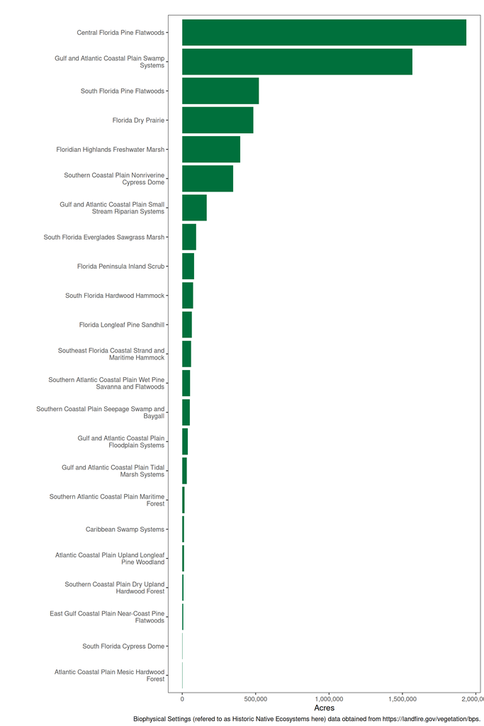

**According to LANDFIRE data, the Historic Native Ecosystems that occurred in less than 1,000 acres in this Ecological Section were:**

- Southern Coastal Plain Mesic Slope Forest
- Atlantic Coastal Plain Dry and Dry-Mesic Oak Forest
- Southwest Florida Coastal Strand and Maritime Hammock
- East Gulf Coastal Plain Interior Upland Longleaf Pine Woodland
- Atlantic Coastal Plain Streamhead Seepage Swamp-Pocosin-Baygall

It is important to note that LANDFIRE data is designed for landscape-level assessments and not designed for analysis of ‘rare’ systems. Please take this into account, explore surrounding ecological sections, and look to more localized sources of information such as State Wildlife Action Plans, NatureServe, and others to better understand the likely historic and current occurrence of these rarer systems.

### Existing Ecosystems Greater than 1,000 acres (as of 2024)

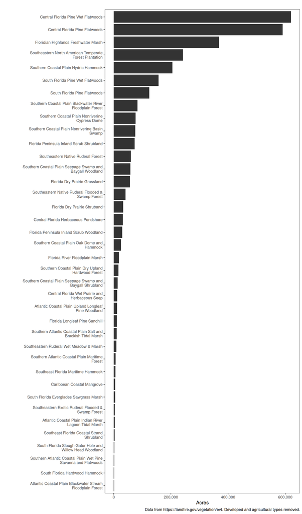

**Existing Vegetation Types that had less than 1,000 acres in this Ecological Section were:**

- South Florida Pond-apple/Popash Slough
- South Florida Dwarf Cypress Savanna
- South Florida Cypress Dome
- South Florida Slough Gator Hole and Willow Head Herbaceous
- South Florida Bayhead Swamp
- South Florida Hydric Hammock
- Southern Coastal Plain Mesic Slope Forest
- Southern Atlantic Coastal Plain Fresh and Oligohaline Tidal Marsh
- Atlantic Coastal Plain Small Blackwater River Floodplain Forest
- South Florida Pine Rockland
- Southeastern Coastal Plain Interdunal Wetland
- Southern Atlantic Coastal Plain Nonriverine Swamp and Wet Hardwood Forest
- Southern Atlantic Coastal Plain Tidal Wooded Swamp
- Atlantic Coastal Plain Blackwater Stream Floodplain Shrubland
- Southern Coastal Plain Herbaceous Seep and Bog
- Caribbean Estuary Mangrove
- Central Atlantic Coastal Plain Wet Longleaf Pine Savanna and Flatwoods

**Historic Native and Existing Ecosystems**

For this Ecological Section:

- LANDFIRE data shows there were **29** Historic Native Ecosystem models (counting regional model variants separately).
- The 10 largest Historic Native Ecosystems covered **93%** of total mapped area in this Ecological Section.
- As of 2024 LANDFIRE mapped **55** Existing Ecosystems for this Ecological Section.
- The 10 largest Existing Vegetation Types (including agricultural, developed, and water types) covered **70%** of total mapped area in this Ecological Section.

### Flow chart: Composition of Existing Ecosystems within the three most prevalent Historic Native Ecosystem footprints

For the charts below we assessed the amounts of each Existing Ecosystem (at a coarse level; includes agricultural and developed types) within each of the top 3 most prevalent Native Ecosystem footprints for this Ecological Section.

**Understanding the Sankey charts:**

- The Historic Native Ecosystem is on the left, coarse-level Existing Ecosystems on the right.
- Hover over the grey horizontal bands to explore how Historic Native Ecosystems have split out to the associated Existing Ecosystems on the current landscape.
- The percent in parentheses on the left is that Historic Native Ecosystem’s share of the three footprints shown (not of the full Ecological Section).

Central Florida Pine Flatwoods (48%)

[interactive chart not shown]

Gulf and Atlantic Coastal Plain Swamp Systems (39%)

[interactive chart not shown]

South Florida Pine Flatwoods (13%)

[interactive chart not shown]

### Summary Table of Conversion

In the table below we summarize conversion of all Historic Native Ecosystem models in this Ecological Section. All area values are in acres. “Natural vegetation remaining” means not Agricultural or Developed (exotic vegetation is counted as remaining). Click on column names to sort.

| Native Ecosystem | Model Code | Total Area | Natural Vegetation Remaining | Converted (Agriculture + Developed) | Percent Natural Vegetation Remaining | pct_num |
| --- | --- | --- | --- | --- | --- | --- |
| Central Florida Pine Flatwoods | 14530_55_56 | 1,935,968 | 1,249,312 | 686,656 | 64.5% | 0.6453164515115952 |
| Gulf and Atlantic Coastal Plain Swamp Systems | 14800_46_56_58_60_64_65_66 | 1,311,574 | 526,635 | 784,939 | 40.2% | 0.4015290025572328 |
| South Florida Pine Flatwoods | 14460_56 | 521,985 | 234,387 | 287,598 | 44.9% | 0.4490301445443834 |
| Florida Dry Prairie | 14250_56 | 484,161 | 231,499 | 252,662 | 47.8% | 0.4781446667534147 |
| Floridian Highlands Freshwater Marsh | 14890_55_56_99 | 395,484 | 364,454 | 31,030 | 92.2% | 0.9215391773118508 |
| Southern Coastal Plain Nonriverine Cypress Dome | 14600_55_56_99 | 346,295 | 318,510 | 27,785 | 92.0% | 0.919764940296568 |
| Gulf and Atlantic Coastal Plain Swamp Systems | 14800_55_99 | 256,655 | 248,708 | 7,947 | 96.9% | 0.969036254894703 |
| Gulf and Atlantic Coastal Plain Small Stream Riparian Systems | 14740_46_47_48_55_56_58_60_99 | 167,398 | 96,823 | 70,575 | 57.8% | 0.5783999808838816 |
| South Florida Everglades Sawgrass Marsh | 14830_56 | 95,002 | 17,293 | 77,709 | 18.2% | 0.1820277467842782 |
| Florida Peninsula Inland Scrub | 13870_55_56 | 80,836 | 12,159 | 68,677 | 15.0% | 0.150415656390717 |

[output cut: 19 more lines]

**Note**

**Consideration:** Before moving on to the next section, think through which ecosystems have been most impacted by conversion. If a system has largely been converted to agricultural and developed land uses AND it has low levels of protection below, it may be worth additional consideration.

## GAP Status

The second step to identifying RSAs (as outlined in Annex G) is to assess the adequacy of representation and protection of the identified native ecosystems within the landscape. This next section provides the first step to making this assessment by showing the percent of each of the existing ecosystems that covered more than 1,000ac and that CE3.1 that are protected in Gap Status 1, 2, or 3 lands. Importantly, this chart does not evaluate “adequate” vs “inadequate” levels of protection and representation, which will be unique to each identiﬁed ecosystem type and its distinct qualities.

**The GAP status codes are defined as (copied from https://www.usgs.gov/programs/gap-analysis-project/gap-status-code-frequently-asked-questions-faq):**

**Gap Status 1:** An area having permanent protection from conversion of natural land cover and a mandated management plan in operation to maintain a natural state within which disturbance events (of natural type, frequency, intensity, and legacy) are allowed to proceed without interference or are mimicked through management.

**Gap Status 2:** An area having permanent protection from conversion of natural land cover and a mandated management plan in operation to maintain a primarily natural state, but which may receive uses or management practices that degrade the quality of existing natural communities, including suppression of natural disturbance.

**Gap Status 3:** An area having permanent protection from conversion of natural land cover for the majority of the area, but subject to extractive uses of either a broad, low intensity type (for example, logging, Off-Highway Vehicle recreation) or localized intense type (for example, mining). It also confers protection to federally listed endangered and threatened species throughout the area.

**GAP status 4 not shown in chart below. Chart is interactive. Hover over bars to get more information.**

[interactive chart not shown]

**Tip**

**Protection Status**

- The lowest observed protection level is **14%**.
- Ecosystems with the least protection include: **Florida Longleaf Pine Sandhill (14%); Southeast Florida Maritime Hammock (16%); Florida Peninsula Inland Scrub Woodland (17%)**.
- The lowest level of strict protection (GAP Status 1) is **0.0%**, with the least represented ecosystems including: **Atlantic Coastal Plain Blackwater Stream Floodplain Forest (0.0%); Atlantic Coastal Plain Upland Longleaf Pine Woodland (0.0%); Florida Longleaf Pine Sandhill (0.0%)**.

## Next Steps – No need to establish RSA(s)

If the result of the assessment conducted using the information above combined with additional research and justification on the part of the certificate holder shows that all native ecosystems are adequately represented or protected in the landscape, then there is no need to establish RSAs within the management unit.

## Next Steps – Need to establish RSA(s)

Per Indicator 6.5.2, if the results of the assessment conducted using the information above combined with additional research and justification on the part of the certificate holder shows that there are native ecosystems that are not adequately represented or protected within the landscape, viable examples of these ecosystems will need to be designated as Representative Sample Areas within the management unit. If there are no viable examples, degraded examples that could be restored need to be designated as RSAs and managed to restore to more natural conditions.

When there is a need for RSAs, designating areas of native ecosystems within your management unit that represent underrepresented successional classes is encouraged, but not required. In these cases, the following sections may be helpful in advising decisions by providing a more in-depth view into levels of representation and protection of different successional classes for each ecosystem.

## Reference vs Current Succession Classes and Historical Disturbances of the Dominant Historic Native Ecosystem

We quantified Historic Native Ecosystems using LANDFIRE’s [Biophysical Settings](https://landfire.gov/vegetation/bps) spatial data, “reference” succession class amounts from LANDFIRE’s [Biophysical Settings Models](https://landfire.gov/vegetation/bps-models), and current amounts of each succession class using LANDFIRE’s [Succession Class](https://landfire.gov/vegetation/sclass%5D) spatial data. See more about these datasets in the “Key Concepts” section below.

Additionally, using the same datasets, we are able to estimate the percent of each Historic Native Ecosystem that is disturbed by specific disturbance types annually.

**Note**

Due to the complexities of multiple variants and scale, we only presentthe most common Historical Native Ecosystem per chart as an example of the analysis that can be conducted for all remaining ecosystems. Please contact Randy Swaty at rswaty@tnc.org, and/or The Nature Conservancy’s LANDFIRE team at landfire@tnc.org for more information. Also see [this GIS guide](https://thenatureconservancy.github.io/landfire-guide/) for instructions on how to do the succession class analysis using ArcGIS Pro and Microsoft Excel.

### Reference vs Current Succession Classes of the Dominant Historic Native Ecosystem

**About the chart that follows:**

- The chart presents the most prevalent Historic Native Ecosystem model in this Ecological Section based on mapped area.
- A Historic Native Ecosystem may have multiple regional variants with different succession classes and reference conditions. The chart therefore uses the single most prevalent Historical Native Ecosystem variant rather than combining variants.
- The chart compares the LANDFIRE reference percentage with the current mapped percentage for each succession class.

**Reading succession class labels:**

- Early, Mid, and Late indicate developmental stages.
- OPN = Open canopy, CLS = Closed canopy, and ALL = All canopy conditions. Each Biophysical Setting has custom Open/Closed canopy positions. See Biophysical Settings description below to read about the species and specific canopy characteristics for each succession class.
- UN indicates “Uncharacteristic Native” vegetation, where the vegetation is native but its current structure was not defined under reference conditions.
- UE indicates “Uncharacteristic Exotic” vegetation.
- The chart compares the reference amount of each succession class to the amount currently mapped within the dominant Historic Native Ecosystem.

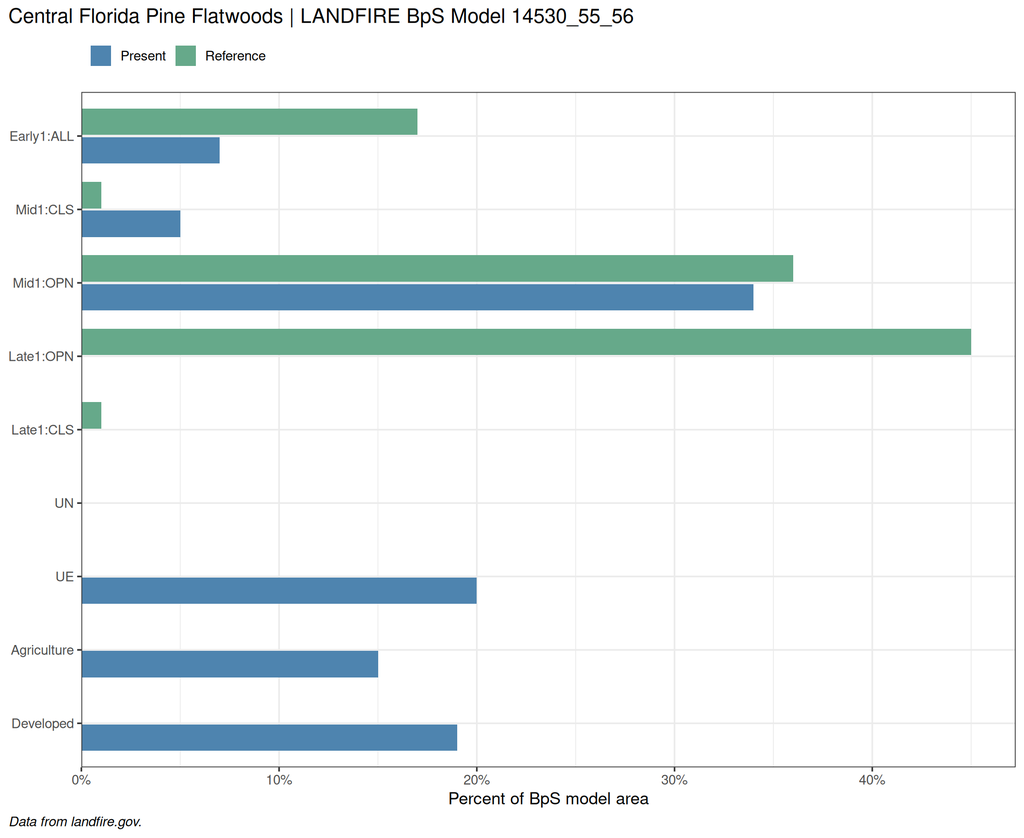

**Reference document for the dominant Historic Native Ecosystem:**

[Central Florida Pine Flatwoods (14530_55_56)](https://github.com/rswaty/bps_docs_parse/raw/main/all_bps_docs/14530_55_56.docx)

### Annual Historical Disturbance Amounts for top Historic Native Ecosystem

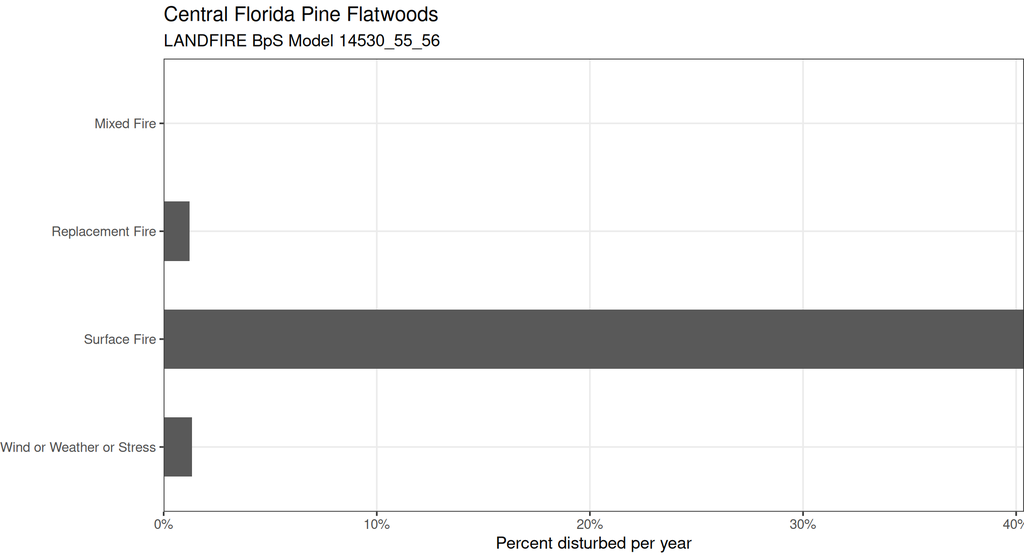

## Key Concepts about the input data from LANDFIRE:

In order to better understand the the quantity of historical ecosystems, their protection status, ecological condition and natural disturbance regimes at a landscape scale, we summarized LANDFIRE and GAP data to Ecological Sections. These summaries are coarse, aimed at setting context and setting the stage for structured analysis of more local management areas.

**Key Concepts about the input data:**

In order to better understand the quantity of historic ecosystems, their protection status, ecological condition and natural disturbance regimes at a landscape scale, we summarized LANDFIRE and GAP data to Ecological Sections. These summaries are coarse, aimed at setting context and setting the stage for structured analysis of more local management areas.

- The Biophysical Settings (BpS) data represents the “habitat” of an ecosystem, based on abiotic factors such as soils, surficial geology, slope, elevation and aspect, plus the current climate. Each BpS has a reference document that describes how it looked and functioned prior to European colonization and a state-and-transition model that estimates how much of each “Succession Class” (see below) would have occurred within the habitat based on best approximations of the natural disturbance regime (referred to below as ‘reference’). The BpSs are based on NatureServe’s Ecological Systems. This data represents ecosystems that “should” occur in the landscape. We call these Historic Native Ecosystems.
- Succession Classes (s-class) are essentially developmental and/or structural stages. There are up to 5 defined for each BpS and are based on lifeform (e.g., broadleaf or needleleaf), and ranges of canopy cover (e.g., 70-80%) and canopy height (e.g., 10-25M ). In addition to modeled estimates of reference percents of each SCL, succession classes are mapped across the US today so that we can compare reference to current amounts.
- Existing Vegetation Type (EVT) data represents the current distribution of NatureServe’s Ecological Systems. Because of subsequent review and improvement, BpS and EVT names and lists for particular places may not always match. This data represents ecosystems that occur in the landscape. [CE9.1]. We call these Existing Ecosystems.
- GAP Status data identifies the level of biodiversity protection provided to ecosystems based on management intent and legal mandates. This information helps assess the extent to which Existing Ecosystems are represented within lands managed for long-term conservation of biodiversity.

## Historic Native Ecosystem Descriptions

To better understand ‘reference’ conditions for the Historic Native Ecosystems of the US, the LANDFIRE program developed descriptions plus accompanying state-and-transition models that depict how these systems ‘looked and functioned’ with natural disturbance regimes. Below you can download the descriptions for this section’s Native Ecosystems and explore the succession class descriptions in a table.

LANDFIRE developed and delivers this information by Map Zone. If an ecosystem crosses multiple Map Zones there may be multiple ‘variants’. In the table of links to the descriptions you will see “Model Codes”, which represent an unique 5 digit code for the system followed by a list of Map Zones that description applies to.

LANDFIRE Map Zones for the lower 48 states

| Native Ecosystem | Model Code | Document |
| --- | --- | --- |
| Southern Coastal Plain Dry Upland Hardwood Forest | 13300_46_48_54_55_56_99 | Southern Coastal Plain Dry Upland Hardwood Forest (13300_46_48_54_55_56_99) |
| South Florida Hardwood Hammock | 13330_56 | South Florida Hardwood Hammock (13330_56) |
| Atlantic Coastal Plain Dry and Dry-Mesic Oak Forest | 13350_55_58_60 | Atlantic Coastal Plain Dry and Dry-Mesic Oak Forest (13350_55_58_60) |
| Southwest Florida Coastal Strand and Maritime Hammock | 13360_56 | Southwest Florida Coastal Strand and Maritime Hammock (13360_56) |
| Southeast Florida Coastal Strand and Maritime Hammock | 13370_56 | Southeast Florida Coastal Strand and Maritime Hammock (13370_56) |
| Atlantic Coastal Plain Mesic Hardwood Forest | 13430_54_55 | Atlantic Coastal Plain Mesic Hardwood Forest (13430_54_55) |
| Atlantic Coastal Plain Upland Longleaf Pine Woodland | 13470_55_58_60 | Atlantic Coastal Plain Upland Longleaf Pine Woodland (13470_55_58_60) |
| East Gulf Coastal Plain Interior Upland Longleaf Pine Woodland | 13490_46_48_54_55_99 | East Gulf Coastal Plain Interior Upland Longleaf Pine Woodland (13490_46_48_54_55_99) |
| Florida Longleaf Pine Sandhill | 13560_55_56_99 | Florida Longleaf Pine Sandhill (13560_55_56_99) |
| Southern Coastal Plain Mesic Slope Forest | 13570_46_47_55_58_99 | Southern Coastal Plain Mesic Slope Forest (13570_46_47_55_58_99) |

[output cut: 19 more lines]